# Porous model example run

## Intro

This poorly written vignette contains some working example of how to run the model in its current state.  
The code is organized in a series of functions:

[interactive chart not shown]

## Example: how to to run the main model function (written within the SoilR model development framework)

```r
library(Porous)
library(SoilR) #this should load automatically anyway since it is required by Porous
```

First we create the model object:

```r
 modelObject<-Porous()
```

This creates a model with the default parameters. The parameter values can also be specified by the user (when one value is not specified the parameter will have default value), such as:

```r
modelObject<-Porous(ky=0.8, ko=0.00605,
                    kmix=0.9,
                    e=0.13,
                    Im=1.1, Ir=0.5,
                    F_prot=0.1,
                    phi_mac=0.2,
                    phi_min=1,
                    clay=0.2,
                    Delta_z_min=20,
                    gamma_o=1.2,
                    f_agg=3)
```

Many values can be omitted, and the function will use the defaults. In particular `f_text_mic`, if omitted, will be calculated internally with a specific function, `f_text_mic_func()`.

`SoilR` has an internal function designed to plot any model (but fluxes do not always seem consistent in the representation):

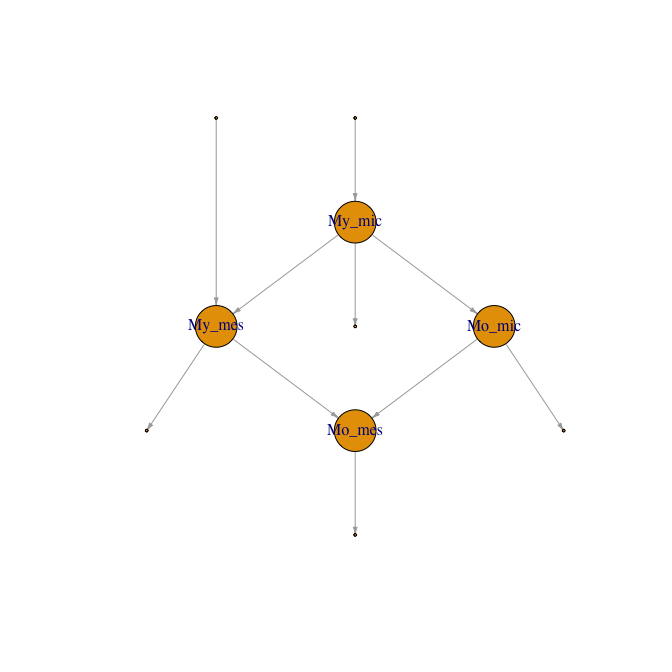

```r
plotPoolGraph(modelObject)
```

Now we can run the model, for which we need to initialize the starting values

```r
init<-c(My_mes=1, Mo_mes=10,My_mic=0.6, Mo_mic=3)
times<-seq(0,20,by=0.1)
```

We can then run the model with the specific `SoilR` function:

```r
modrun0<-Model_by_PoolNames(smod=modelObject, times=times, initialValues=init)
```

And, again relying on the specific `SoilR` function, we can extract the C stocks and respiration fluxes:

```r
Stocks<-getC(modrun0)
Resp<-getReleaseFlux(modrun0)
```

Let’s see what object we created (by plotting just the first rows of it):

```r
head(Resp)
```

```
#>           [,1] [,2]       [,3]        [,4]
#> [1,] 0.6960000    0 0.04176000 0.001579050
#> [2,] 0.7069930    0 0.04583590 0.001882993
#> [3,] 0.7202573    0 0.04955593 0.002137364
#> [4,] 0.7350393    0 0.05298300 0.002350339
#> [5,] 0.7507724    0 0.05616618 0.002528744
#> [6,] 0.7670322    0 0.05914384 0.002678287
```

Everything seems in order and we can proceed to plot:

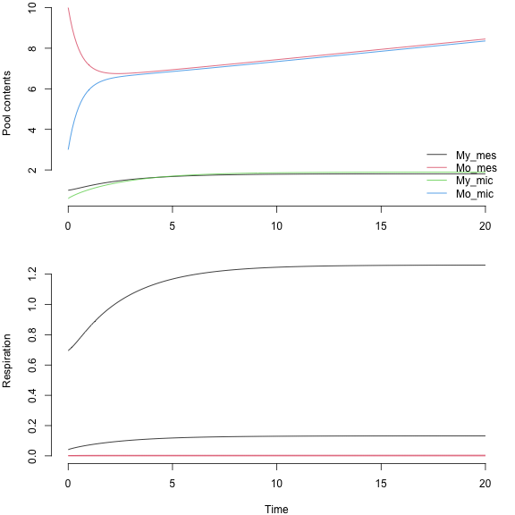

```r
par(mfrow=c(2,1), mar=c(4,4,0,1))
matplot(times, Stocks, type="l", lty=1, col=1:4, xlab=" ", ylab="Pool contents", bty="n")
legend("bottomright", c("My_mes", "Mo_mes", "My_mic", "Mo_mic"), lty=1, col=1:4, bty="n")
matplot(times, Resp,  type="l", lty=1, col=1:2, xlab="Time", ylab="Respiration", bty="n")
```

```r
f_som(My_mic=Stocks[1:20,1],
      Mo_mic=Stocks[1:20,2],
      My_mes=Stocks[1:20,3],
      Mo_mes=Stocks[1:20,4],
      Delta_z_min=20,
      phi_min=0.35,
      gamma_m=1.1)
```

```
#>  [1] 0.5051903 0.5066468 0.5080669 0.5094489 0.5107916 0.5120950 0.5133593
#>  [8] 0.5145852 0.5157737 0.5169259 0.5180431 0.5191266 0.5201777 0.5211977
#> [15] 0.5221878 0.5231494 0.5240837 0.5249918 0.5258749 0.5267340
```

```r
gamma_b(My_mic=Stocks[1:20,1],
        Mo_mic=Stocks[1:20,2],
        My_mes=Stocks[1:20,3],
        Mo_mes=Stocks[1:20,4],
        Delta_z_min=20,
        phi_min=1,
        gamma_o=1.2,
        gamma_m=1.1,
        f_agg=3,
        phi_mac=0.2)
```

```
#>  [1] 0.1700971 0.1703854 0.1706659 0.1709382 0.1712022 0.1714579 0.1717054
#>  [8] 0.1719449 0.1721767 0.1724010 0.1726180 0.1728282 0.1730317 0.1732288
#> [15] 0.1734199 0.1736052 0.1737849 0.1739593 0.1741287 0.1742933
```

## Running the model with the wrapper (more comfortable, less transparent)

All the above functions can be run with a wrapper, `run_Porous`, that takes care of running the simulation and calculating bulk density, C concentration and layer thickness evolution:

```r
simulation<-run_Porous(ky=0.8, ko=0.04,
                     kmix=0.02,
                     e=0.15,
                     Im=0.08, Ir=0.048,
                     F_prot=0.1,
                     phi_mac=0.04,
                     clay=0.2,
                     Delta_z_min=14.2,
                     gamma_o=1.2,
                     gamma_m=2.7,
                     proportion=NULL,
                     phi_min=0.35,
                     f_text_mic=0.5069,
                     f_agg=3,
                     init=c(My_mes=0.132, Mo_mes=0.507, My_mic=0.284, Mo_mic=0.579),
                     sim_length=20,
                     sim_steps=0.1)

simulation$`mass balance`
```

```
#> [1] 2.560000 2.560623
```

```r
results<-simulation$results

head(results)
```

```
#>   time My_mes.stocks Mo_mes.stocks My_mic.stocks Mo_mic.stocks My_mes.resp
#> 1  0.0     0.1320000     0.5070000     0.2840000     0.5790000  0.08976000
#> 2  0.1     0.1436485     0.5087969     0.2718964     0.5789944  0.09768101
#> 3  0.2     0.1543548     0.5107245     0.2599356     0.5789782  0.10496128
#> 4  0.3     0.1641962     0.5127712     0.2481141     0.5789517  0.11165345
#> 5  0.4     0.1732404     0.5149268     0.2364291     0.5789154  0.11780350
#> 6  0.5     0.1815503     0.5171819     0.2248776     0.5788696  0.12345420
#>   Mo_mes.resp My_mic.resp Mo_mic.resp  f_som_sim gamma_b_sim Delta_z_sim
#> 1           0  0.01931200 0.001968600 0.05684442    1.320691    20.00694
#> 2           0  0.01848896 0.001968581 0.05689211    1.320452    20.01158
#> 3           0  0.01767562 0.001968526 0.05691555    1.320334    20.01386
#> 4           0  0.01687176 0.001968436 0.05691699    1.320327    20.01400
#> 5           0  0.01607718 0.001968312 0.05689837    1.320421    20.01219
#> 6           0  0.01529168 0.001968157 0.05686153    1.320605    20.00861
```

The wrapper first runs a C stocks simulation (including with variable layer thickness calculation) and then it uses the C stocks from the simulation to calculate again the layer thickness and calculate for the first time SOC concentration and soil bulk density to include these variables in the results. This is done because it is not possible (or I do not know the way) to export the internal calculations from the SoilR model.  
Please notice that the above code is overriding the `f_text_mic` calculation.

Results can be accessed as plotted as a data frame:

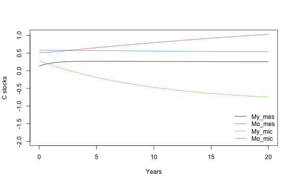

```r
range_stocks<-range(results[,2:5])
plot(results$time, results$My_mes.stocks, ylim=c(-2,range_stocks[2]), type="l", col=1, xlab="Years", ylab="C stocks")
lines(results$time, results$Mo_mes.stocks, ylim=range_stocks, type="l", col=2)
lines(results$time, results$My_mic.stocks, ylim=range_stocks, type="l", col=3)
lines(results$time, results$Mo_mic.stocks, ylim=range_stocks, type="l", col=4)
legend("bottomright", c("My_mes", "Mo_mes", "My_mic", "Mo_mic"), lty=1, col=1:4, bty="n")
```

The `run_Porous`: function, on top of the simulation of C stocks from the main model function `porous`, gives also the simulated evolution of bulk density, the C concentration and layer thickness:

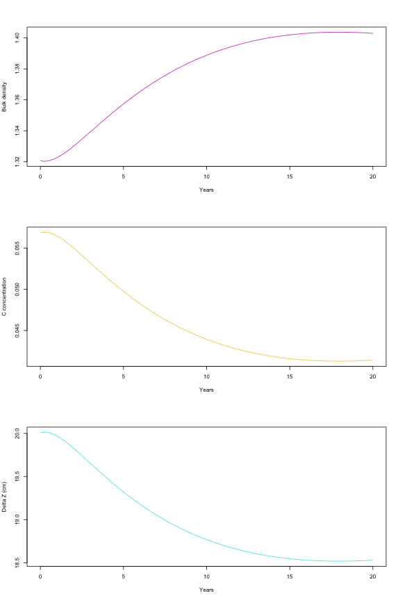

```r
par(mfrow=c(3,1))
plot(results$time, results$gamma_b_sim,  type="l", col=6, xlab="Years", ylab="Bulk density")
plot(results$time, results$f_som_sim,  type="l", col=7, xlab="Years", ylab="C concentration")
plot(results$time, results$Delta_z_sim,  type="l", col=5, xlab="Years", ylab="Delta Z (cm)")
```

## Example: how to to run the model (written directly with a deSolve wrapper)

The package contains an alternative implementation of the same model, directly written around the `deSolve` package (but wrapped to have the same syntax). The following is an example of a model run at equilibrium (so the pools are supposed to be flat):

```r
simulation_deSolve<-run_Porous_deSolve(ky=0.8, ko=0.04,
                                        kmix=0.02,
                                        e=0.15,
                                        Im=0.08, Ir=0.048,
                                        F_prot=0.1,
                                        phi_mac=0.04,
                                        clay=0.2,
                                        Delta_z_min=14.2,
                                        gamma_o=1.2,
                                        gamma_m=2.7,
                                        proportion=NULL,
                                        phi_min=0.35,
                                        f_text_mic=0.5069,
                                        f_agg=3,
                                        init=c(My_mes=0.132, Mo_mes=0.507, My_mic=0.284, Mo_mic=0.579),
                                        sim_length=30,
                                        sim_steps=0.1,
                                        constant=T)

results_deSolve<-simulation_deSolve$results

head(results_deSolve)
```

```
#>   time My_mes.stocks Mo_mes.stocks My_mic.stocks Mo_mic.stocks  f_som_sim
#> 1  0.0     0.1320000     0.5070000     0.2840000     0.5790000 0.05684442
#> 2  0.1     0.1322677     0.5070058     0.2836908     0.5789998 0.05684313
#> 3  0.2     0.1325133     0.5070146     0.2833857     0.5789992 0.05684130
#> 4  0.3     0.1327387     0.5070262     0.2830843     0.5789982 0.05683897
#> 5  0.4     0.1329451     0.5070404     0.2827868     0.5789970 0.05683618
#> 6  0.5     0.1331345     0.5070568     0.2824930     0.5789954 0.05683298
#>   gamma_b_sim Delta_z_sim
#> 1    1.320691    20.00694
#> 2    1.320698    20.00682
#> 3    1.320707    20.00664
#> 4    1.320719    20.00641
#> 5    1.320733    20.00614
#> 6    1.320749    20.00583
```

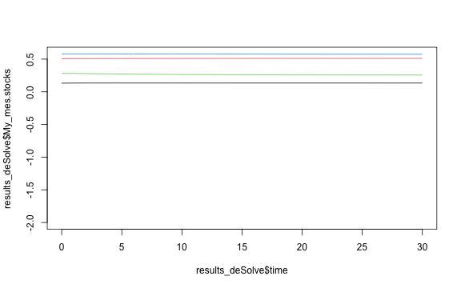

```r
range_stocks<-range(results_deSolve[,2:5])
plot(results_deSolve$time, results_deSolve$My_mes.stocks, ylim=c(-2,range_stocks[2]), type="l", col=1)
lines(results_deSolve$time, results_deSolve$Mo_mes.stocks, col=2)
lines(results_deSolve$time, results_deSolve$My_mic.stocks, col=3)
lines(results_deSolve$time, results_deSolve$Mo_mic.stocks, col=4)
```

You should pay attention to the option `constant`, default is `FALSE`. When `TRUE` the solver runs in a version for constant inputs, when `FALSE` the solver run instead assuming that `inputs` are a vector of the same length than `sim_length` and it makes it a continuous function with the R base function `approxfun` which is then caller inside the ODE given to the solver.

```r
sim_length=30

simulation_deSolve<-run_Porous_deSolve(ky=0.8, ko=0.04,
                                        kmix=0.02,
                                        e=0.15,
                                        Im=rep(0.08, sim_length), Ir=rep(0.048, sim_length),
                                        F_prot=0.1,
                                        phi_mac=0.04,
                                        clay=0.2,
                                        Delta_z_min=14.2,
                                        gamma_o=1.2,
                                        gamma_m=2.7,
                                        proportion=NULL,
                                        phi_min=0.35,
                                        f_text_mic=0.5069,
                                        f_agg=3,
                                        init=c(My_mes=0.132, Mo_mes=0.507, My_mic=0.284, Mo_mic=0.579),
                                        sim_length=sim_length,
                                        sim_steps=0.1,
                                       constant=F)

results_deSolve<-simulation_deSolve$results

head(results_deSolve)
```

```
#>   time My_mes.stocks Mo_mes.stocks My_mic.stocks Mo_mic.stocks  f_som_sim
#> 1  0.0     0.1320000     0.5070000     0.2840000     0.5790000 0.05684442
#> 2  0.1     0.1322677     0.5070058     0.2836908     0.5789998 0.05684313
#> 3  0.2     0.1325133     0.5070146     0.2833857     0.5789992 0.05684130
#> 4  0.3     0.1327387     0.5070262     0.2830843     0.5789982 0.05683897
#> 5  0.4     0.1329451     0.5070404     0.2827868     0.5789970 0.05683618
#> 6  0.5     0.1331345     0.5070568     0.2824930     0.5789954 0.05683298
#>   gamma_b_sim Delta_z_sim
#> 1    1.320691    20.00694
#> 2    1.320698    20.00682
#> 3    1.320707    20.00664
#> 4    1.320719    20.00641
#> 5    1.320733    20.00614
#> 6    1.320749    20.00583
```

Results are in this case the same since we are just repeating the same inputs as a constant vector over the whole simulation, but that vector now can be variable.

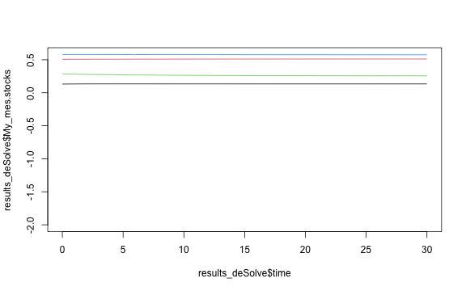

```r
range_stocks<-range(results_deSolve[,2:5])
plot(results_deSolve$time, results_deSolve$My_mes.stocks, ylim=c(-2,range_stocks[2]), type="l", col=1)
lines(results_deSolve$time, results_deSolve$Mo_mes.stocks, col=2)
lines(results_deSolve$time, results_deSolve$My_mic.stocks, col=3)
lines(results_deSolve$time, results_deSolve$Mo_mic.stocks, col=4)
```